# Home Credit Default Risk

Modeling

Roman Brock, Che Diaz Fadel, Kalyani Joshi, and Chris Porter

# 1 Introduction

Unbanked individuals represent both an underserved demographic as well as a typically untapped market by reputable creditors. Home Credit seeks to fill this gap in service. There are unique challenges that accompany establishing creditworthiness among a population that by definition has little to no financial history, verifiable assets, or traditional means to qualify for a loan.

## 1.1 Project Scope

This project will utilize machine learning algorithms to develop a classification model which will use available data about Home Credit customers to improve prediction of those that are likely to repay loans granted by Home Credit. The team will test a number of possible classification models in order to develop the most accurate model on data outside the training data. A successful model will provide greater perfomance in terms of limiting Type II errors, than a simple prediction based upon majority class statistics and will allow Home Credit to loan to customers with confidence that repayment will in return grow available assets to the company in order to further its mission of providing credit to the underserved.

The dataset was previously explored and was determined to be suitable for data modelling purposes. In this notebook we document the various modeling strategies explored as well as any included data preparation undertaken prior to modeling. We then compare the various models performance and report our results.

# 2 Data Preparation

## 2.1 Load Libraries

```r
# xgBoost dependencies
library(tidyverse)
library(gmodels)
library(caret)
library(mlr)
library(xgboost)
library(parallel)
library(parallelMap)
library(ggplot2)
library(pROC)
library(skimr)
library(randomForest)
library(ROCR)
library(ROSE)
library(mlr)
```

## 2.2 Standardized Data Set Preparation

In accordance with the information detailed in our previous EDA notebook, we created a standardized data set that utilized the same variables for all models.

```r
# Load data ----
app_train <- read_csv("../data/application_train.csv")

bureau_df <- read_csv("../data/bureau.csv")

desired_columns <- read_csv("desired_columns.csv")

# Identify numerically encoded categorical variables ----
num2fac <- app_train %>%
  select(where(is.numeric)) %>%
  mutate(across(everything(), as.character)) %>%
  select(where(~ all(!grepl("\\.|-", .)))) %>%
  #select(-c(own_car_age, hour_appr_process_start, matches("^(obs|def|amt|cnt)"))) %>%
  select(-c(OWN_CAR_AGE, HOUR_APPR_PROCESS_START, matches("^(OBS|DEF|AMY|CNT)"))) %>%
  colnames()

# Create data frame ----
app_train1 <- app_train %>%
  # Select columns from 'desired_columns.csv'
  select(desired_columns$ColumnName) %>%
  # Handling numerically encoded categorical variables
  mutate(across(c(where(is.character), all_of(num2fac)), factor),
         # Fixing invalid NA's
         across(c(CODE_GENDER, ORGANIZATION_TYPE),
                ~case_when(. != "XNA" ~ .)),
         # Replacing NA's in social circle columns with 0
         across(contains("SOCIAL_CIRCLE"), ~replace_na(., 0)),
         # Replacing NA's with 0
         across(c(AMT_REQ_CREDIT_BUREAU_HOUR, AMT_REQ_CREDIT_BUREAU_DAY,
                  AMT_REQ_CREDIT_BUREAU_WEEK, AMT_REQ_CREDIT_BUREAU_MON,
                  AMT_REQ_CREDIT_BUREAU_QRT, AMT_REQ_CREDIT_BUREAU_YEAR),
                ~replace_na(., factor("0"))),
         # Fixing unusual `DAYS_EMPLOYED` values
         DAYS_EMPLOYED = case_when(DAYS_EMPLOYED <= 0 ~ DAYS_EMPLOYED),
         # Creating ordinal version of `OWN_CAR_AGE`
         OWN_CAR_AGE2 = cut(OWN_CAR_AGE,
                            c(0, 5, 10, 15, Inf),
                            right = FALSE),
         OWN_CAR_AGE2 = case_when(FLAG_OWN_CAR == "N" ~ factor("No Car Owned"),
                                  .default = OWN_CAR_AGE2)) %>%
  # Creating aggregate variable from the `EXT_SOURCE_*` variables
  rowwise() %>%
  mutate(AVG_EXT_SCORE = mean(c_across(contains("EXT_"))),
         .after = EXT_SOURCE_3) %>%
  ungroup() %>%
  # Removing rows with NA's in below columns
  filter(if_all(c(FLAG_OWN_CAR, AMT_GOODS_PRICE, AMT_ANNUITY,
                  CNT_FAM_MEMBERS, DAYS_LAST_PHONE_CHANGE),
                ~!is.na(.)))

# Aggregate bureau data ----
# __ Wide version data frame
bureau_agg_a <- bureau_df %>%
  # Seemed to be the most relevant credit types
  filter(CREDIT_TYPE %in% c("Consumer credit","Credit card","Car loan","Mortgage",
                            "Microloan","Loan for business development","Another type of loan"),
         # Ensure credit was actually given
         AMT_CREDIT_SUM > 0,
         # Thought this made most sense
         CREDIT_ACTIVE %in% c("Active", "Closed"),
         # It's unclear if they convert nominal curreny values so kept only most common
         CREDIT_CURRENCY == "currency 1") %>%
  # Clean credit type values to use as column names
  mutate(CREDIT_TYPE = gsub(" +", "_", tolower(CREDIT_TYPE))) %>%
  group_by(SK_ID_CURR, CREDIT_TYPE) %>%
  summarise(avg_credit = mean(AMT_CREDIT_SUM),
            # Decided that average of ratios made more sense than ratio of averages
            avg_overage = mean(AMT_CREDIT_MAX_OVERDUE/AMT_CREDIT_SUM, na.rm = TRUE)) %>%
  pivot_wider(names_from = CREDIT_TYPE,
              values_from = c(avg_credit, avg_overage)) %>%
  ungroup()

# __ Version in EDA ----
bureau_agg_b <- bureau_df %>%
  group_by(SK_ID_CURR) %>%
  summarise(avg_days_credit = mean(DAYS_CREDIT, na.rm = TRUE),
            avg_credit_day_overdue = mean(CREDIT_DAY_OVERDUE, na.rm = TRUE),
            avg_days_credit_enddate = mean(DAYS_CREDIT_ENDDATE, na.rm = TRUE),
            avg_amt_credit_max_overdue = mean(AMT_CREDIT_MAX_OVERDUE, na.rm = TRUE),
            avg_cnt_credit_prolong = mean(CNT_CREDIT_PROLONG, na.rm = TRUE),
            avg_amt_credit_sum = mean(AMT_CREDIT_SUM, na.rm = TRUE),
            avg_amt_credit_sum_debt = mean(AMT_CREDIT_SUM_DEBT, na.rm = TRUE),
            avg_amt_credit_sum_limit = mean(AMT_CREDIT_SUM_LIMIT, na.rm = TRUE),
            avg_amt_credit_sum_overdue = mean(AMT_CREDIT_SUM_OVERDUE, na.rm = TRUE))

#Convert bureau_agg_b$SK_ID_CURR to factor
bureau_agg_b$SK_ID_CURR <- as.factor(bureau_agg_b$SK_ID_CURR)
#Join app_train1 and bureau_agg_b
app_train2 <- app_train1 %>% inner_join(bureau_agg_b)
# Cleanup
remove(app_train,bureau_agg_a,bureau_agg_b,bureau_df,desired_columns,num2fac)
```

This resulted in two datasets app_train1 which contained only information from the application_train.csv dataset, and app_train2 which contained the same information as app_train1, but added aggregated data from bureau.csv.

In addition to this data preparation, some models required specific treatment of the data to get it into a format that was able to be utilized by that particular model.

## 2.3 XGBoost

The XGBoost algorithm requires the use of a numeric matrix. As such, categorical variables were converted into one-hot encoded dummy variables and boolean values were converted into numeric variables. Additionally, non-informative ID variable SK_ID_CURR was removed from the matrix and saved for later analysis.

```r
app_train1 <- readRDS('app_train1.RDS')
app_train2 <- readRDS('app_train2.RDS')

# Create Train and Test sets for Modeling
set.seed(1234)
train.index <- sample(nrow(app_train1), floor(nrow(app_train1)*0.7), replace = F)
train_df <- app_train1[train.index,]
test_df <- app_train1[-train.index,]
remove(train.index, app_train1)

#Verify Target variable distribution in Train and Test
CrossTable(train_df$TARGET)
CrossTable(test_df$TARGET)

ratio <- (sum(ifelse(train_df$TARGET == '0',1,0)))/(sum(ifelse(train_df$TARGET == '1',1,0))) # Ratio Negative Response : Positive Response

# Handle IDs
id.train <- train_df$SK_ID_CURR
id.test <- test_df$SK_ID_CURR
target.train <- ifelse(train_df$TARGET == '1',1,0)
target.test <- ifelse(test_df$TARGET == '1',1,0)
train <- train_df %>% select(-c(SK_ID_CURR,TARGET,OWN_CAR_AGE)) # Add TARGET
test <- test_df %>% select(-c(SK_ID_CURR,TARGET,OWN_CAR_AGE)) # Add TARGET

# Convert Factor Variables to Numeric (Train)
train_df <- train_df %>% select(-c(SK_ID_CURR,OWN_CAR_AGE)) # Add TARGET
test_df <- test_df %>% select(-c(SK_ID_CURR,OWN_CAR_AGE)) # Add TARGET

train_df$TARGET <- ifelse(train_df$TARGET == '1',1,0) # TARGET
train_df$FLAG_OWN_CAR <- ifelse(train_df$FLAG_OWN_CAR == 'Y',1,0) # FLAG_OWN_CAR
train_df$FLAG_OWN_REALTY <- ifelse(train_df$FLAG_OWN_REALTY == 'Y',1,0) # FLAG_OWN_REALTY
for(c in 1:length(colnames(train_df))){
  if(grepl('FLAG_',colnames(train_df)[c])){
    train_df[,c] <- ifelse(train_df[,c] == '1',1,0) # Convert FLAG_ Factor columns to numeric
  } else if (grepl('REG_', colnames(train_df)[c])) {
    train_df[,c] <- ifelse(train_df[,c] == '1',1,0) # Convert REG_ Factor columns to numeric
  } else if (grepl('LIVE_', colnames(train_df)[c])) {
    train_df[,c] <- ifelse(train_df[,c] == '1',1,0) # Convert LIVE_ Factor columns to numeric
  } else if (grepl('AMT_REQ_CREDIT_BUREAU_', colnames(train_df)[c])) {
    train_df[c] <- lapply(train_df[c], function(x) as.numeric(as.character(x))) # Convert Credit Bureau Inquiries Columns to numeric
  }
}

# Convert Factor Variables to Numeric (Test)
test_df$TARGET <- ifelse(test_df$TARGET == '1',1,0) # TARGET
test_df$FLAG_OWN_CAR <- ifelse(test_df$FLAG_OWN_CAR == 'Y',1,0) # FLAG_OWN_CAR
test_df$FLAG_OWN_REALTY <- ifelse(test_df$FLAG_OWN_REALTY == 'Y',1,0) # FLAG_OWN_REALTY
for(c in 1:length(colnames(test_df))){
  if(grepl('FLAG_',colnames(test_df)[c])){
    test_df[,c] <- ifelse(test_df[,c] == '1',1,0) # Convert FLAG_ Factor columns to numeric
  } else if (grepl('REG_', colnames(test_df)[c])) {
    test_df[,c] <- ifelse(test_df[,c] == '1',1,0) # Convert REG_ Factor columns to numeric
  } else if (grepl('LIVE_', colnames(test_df)[c])) {
    test_df[,c] <- ifelse(test_df[,c] == '1',1,0) # Convert LIVE_ Factor columns to numeric
  } else if (grepl('AMT_REQ_CREDIT_BUREAU_', colnames(test_df)[c])) {
    test_df[c] <- lapply(test_df[c], function(x) as.numeric(as.character(x))) # Convert Credit Bureau Inquiries Columns to numeric
  }
}

#Convert remaining Factor variables to dummy variables
dummy <- dummyVars(" ~ .", data=train_df)
dtrain_df <- data.frame(predict(dummy, newdata=train_df))
dummy <- dummyVars(" ~ .", data=test_df)
dtest_df <- data.frame(predict(dummy, newdata=test_df))

#Return TARGET to factor variable
dtrain_df$TARGET <- as.factor(dtrain_df$TARGET)
dtest_df$TARGET <- as.factor(dtest_df$TARGET)
```

## 2.4 Data Pre-processing for Logistic Regression

```r
#Taking joined data to new variable
data_ktrain <-app_train2

#Function to calculate missing percentage
calculate_missing_percentage <- function(data) {
  missing_count <- colSums(is.na(data))
  missing_percentage <- missing_count / nrow(data) * 100
  result <- data.frame(Column = names(missing_count), Missing_Percentage = missing_percentage)
  result$Missing_Percentage <- sprintf("%.2f%%", result$Missing_Percentage)
  result <- result[result$Missing_Percentage != "0.00%", , drop = FALSE]
  result <- result[order(result$Missing_Percentage, decreasing = TRUE), , drop = FALSE]
  return(result)
}

#See missing percentage data
print(calculate_missing_percentage(data_ktrain))
```

```
##                                                Column Missing_Percentage
## avg_amt_credit_sum_limit     avg_amt_credit_sum_limit              7.99%
## OWN_CAR_AGE                               OWN_CAR_AGE             65.14%
## EXT_SOURCE_3                             EXT_SOURCE_3              6.94%
## EXT_SOURCE_1                             EXT_SOURCE_1             55.65%
## APARTMENTS_AVG                         APARTMENTS_AVG             50.26%
## HOUSETYPE_MODE                         HOUSETYPE_MODE             49.68%
## OCCUPATION_TYPE                       OCCUPATION_TYPE             31.21%
## avg_amt_credit_max_overdue avg_amt_credit_max_overdue             30.21%
## avg_amt_credit_sum_debt       avg_amt_credit_sum_debt              2.79%
## DAYS_EMPLOYED                           DAYS_EMPLOYED             17.85%
## ORGANIZATION_TYPE                   ORGANIZATION_TYPE             17.85%
## avg_days_credit_enddate       avg_days_credit_enddate              0.85%
## NAME_TYPE_SUITE                       NAME_TYPE_SUITE              0.35%
## EXT_SOURCE_2                             EXT_SOURCE_2              0.20%
## AVG_EXT_SCORE                           AVG_EXT_SCORE              0.03%
```

```r
# Handle missing values ----
# Drop columns with more than 49% missing data
missing_threshold <- 0.6
data_ktrain_clean <- data_ktrain %>%
    select(where(~ mean(!is.na(.)) > 1 - missing_threshold))

print(calculate_missing_percentage(data_ktrain_clean))
```

```
##                                                Column Missing_Percentage
## avg_amt_credit_sum_limit     avg_amt_credit_sum_limit              7.99%
## EXT_SOURCE_3                             EXT_SOURCE_3              6.94%
## EXT_SOURCE_1                             EXT_SOURCE_1             55.65%
## APARTMENTS_AVG                         APARTMENTS_AVG             50.26%
## HOUSETYPE_MODE                         HOUSETYPE_MODE             49.68%
## OCCUPATION_TYPE                       OCCUPATION_TYPE             31.21%
## avg_amt_credit_max_overdue avg_amt_credit_max_overdue             30.21%
## avg_amt_credit_sum_debt       avg_amt_credit_sum_debt              2.79%
## DAYS_EMPLOYED                           DAYS_EMPLOYED             17.85%
## ORGANIZATION_TYPE                   ORGANIZATION_TYPE             17.85%
## avg_days_credit_enddate       avg_days_credit_enddate              0.85%
## NAME_TYPE_SUITE                       NAME_TYPE_SUITE              0.35%
## EXT_SOURCE_2                             EXT_SOURCE_2              0.20%
## AVG_EXT_SCORE                           AVG_EXT_SCORE              0.03%
```

```r
#Data Imputation
# Numeric variables
data_ktrain_clean$avg_amt_credit_sum_limit <- ifelse(is.na(data_ktrain_clean$avg_amt_credit_sum_limit),
                                              mean(data_ktrain_clean$avg_amt_credit_sum_limit, na.rm = TRUE),
                                              data_ktrain_clean$avg_amt_credit_sum_limit)
data_ktrain_clean$EXT_SOURCE_3 <- ifelse(is.na(data_ktrain_clean$EXT_SOURCE_3),
                                   median(data_ktrain_clean$EXT_SOURCE_3, na.rm = TRUE),
                                   data_ktrain_clean$EXT_SOURCE_3)
data_ktrain_clean$avg_amt_credit_max_overdue <- ifelse(is.na(data_ktrain_clean$avg_amt_credit_max_overdue),
                                                 mean(data_ktrain_clean$avg_amt_credit_max_overdue, na.rm = TRUE),
                                                 data_ktrain_clean$avg_amt_credit_max_overdue)
data_ktrain_clean$avg_amt_credit_sum_debt <- ifelse(is.na(data_ktrain_clean$avg_amt_credit_sum_debt),
                                              mean(data_ktrain_clean$avg_amt_credit_sum_debt, na.rm = TRUE),
                                              data_ktrain_clean$avg_amt_credit_sum_debt)
data_ktrain_clean$DAYS_EMPLOYED <- ifelse(is.na(data_ktrain_clean$DAYS_EMPLOYED),
                                    median(data_ktrain_clean$DAYS_EMPLOYED, na.rm = TRUE),
                                    data_ktrain_clean$DAYS_EMPLOYED)
data_ktrain_clean$avg_days_credit_enddate <- ifelse(is.na(data_ktrain_clean$avg_days_credit_enddate),
                                              median(data_ktrain_clean$avg_days_credit_enddate, na.rm = TRUE),
                                              data_ktrain_clean$avg_days_credit_enddate)

# Categorical variables
data_ktrain_clean$OCCUPATION_TYPE <- ifelse(is.na(data_ktrain_clean$OCCUPATION_TYPE),
                                      levels(data_ktrain_clean$OCCUPATION_TYPE)[which.max(table(data_ktrain_clean$OCCUPATION_TYPE))],
                                      data_ktrain_clean$OCCUPATION_TYPE)
data_ktrain_clean$ORGANIZATION_TYPE <- ifelse(is.na(data_ktrain_clean$ORGANIZATION_TYPE),
                                        levels(data_ktrain_clean$ORGANIZATION_TYPE)[which.max(table(data_ktrain_clean$ORGANIZATION_TYPE))],
                                        data_ktrain_clean$ORGANIZATION_TYPE)
data_ktrain_clean$NAME_TYPE_SUITE <- ifelse(is.na(data_ktrain_clean$NAME_TYPE_SUITE),
                                      levels(data_ktrain_clean$NAME_TYPE_SUITE)[which.max(table(data_ktrain_clean$NAME_TYPE_SUITE))],
                                      data_ktrain_clean$NAME_TYPE_SUITE)
data_ktrain_clean$EXT_SOURCE_2 <- ifelse(is.na(data_ktrain_clean$EXT_SOURCE_2),
                                         median(data_ktrain_clean$EXT_SOURCE_2, na.rm = TRUE),
                                         data_ktrain_clean$EXT_SOURCE_2)
```

```r
# Upsampling the data

# Set seed for reproducibility
set.seed(123)

# Split data into training and testing sets
train_indices_glm <- sample(1:nrow(data_ktrain_clean), 0.7 * nrow(data_ktrain_clean))
train_glm <- data_ktrain_clean[train_indices_glm, ]
test_glm <- data_ktrain_clean[-train_indices_glm, ]

# Check the class distribution of the response variable
table(train_glm$TARGET)
```

```
##
##      0      1
## 169993  14282
```

```r
# Upsample the minority class (positive class) in the training data using DMwR
train_glm_upsampled <- ovun.sample(TARGET ~ ., data = train_glm, method = "both", p = 0.5, seed = 123)$data

# Verify the class distribution of the upsampled training data
table(train_glm_upsampled$TARGET)
```

```
##
##     0     1
## 21196 20657
```

```r
#Excluding SK_ID_CURR column
selected_features <- names(train_glm_upsampled)[2:86]
selected_features <- selected_features[sapply(train_glm_upsampled[selected_features], function(x) length(unique(x))) > 1]
```

Before upsampling, the class distribution is imbalanced, with Class 0 (the majority class) having significantly more observations than Class 1 (the minority class). This class imbalance can impact the performance of the logistic regression model, as it may be biased towards the majority class.

## 2.5 Random Forest

Random Forest models (at least in this package) have limits on the amount of levels in factored predictors and also don’t play well with excessive numbers of NA values.

```r
head(app_train2)
summary(app_train2)

## Removing columns with many NAs / little variation
app_train3 <- app_train2 %>% select(-c(OWN_CAR_AGE,
                                       SK_ID_CURR, AVG_EXT_SCORE, EXT_SOURCE_1, avg_amt_credit_max_overdue,
                                       FLAG_DOCUMENT_10, FLAG_DOCUMENT_11, FLAG_DOCUMENT_12,
                                       FLAG_DOCUMENT_13, FLAG_DOCUMENT_14, FLAG_DOCUMENT_15,
                                       FLAG_DOCUMENT_16, FLAG_DOCUMENT_17, FLAG_DOCUMENT_18,
                                       FLAG_DOCUMENT_19, FLAG_DOCUMENT_20, FLAG_DOCUMENT_21,
                                       FLAG_DOCUMENT_2, FLAG_DOCUMENT_3, FLAG_DOCUMENT_4,
                                       FLAG_DOCUMENT_5, FLAG_DOCUMENT_6, FLAG_DOCUMENT_7,
                                       FLAG_DOCUMENT_8, FLAG_DOCUMENT_9, APARTMENTS_AVG,
                                       OBS_30_CNT_SOCIAL_CIRCLE, OBS_60_CNT_SOCIAL_CIRCLE, DEF_30_CNT_SOCIAL_CIRCLE,
                                       DEF_60_CNT_SOCIAL_CIRCLE, WEEKDAY_APPR_PROCESS_START, HOUR_APPR_PROCESS_START,
                                       AMT_REQ_CREDIT_BUREAU_HOUR, AMT_REQ_CREDIT_BUREAU_QRT, HOUSETYPE_MODE, OCCUPATION_TYPE, EXT_SOURCE_3,
                                       avg_amt_credit_sum_limit, AMT_REQ_CREDIT_BUREAU_WEEK, ORGANIZATION_TYPE))

#Remove empty levels
levels(app_train3$NAME_TYPE_SUITE)[1] = "Missing"

#Replace NA values w/ 0
app_train3 <- app_train3 %>%
          mutate(DAYS_EMPLOYED = coalesce(DAYS_EMPLOYED, 0))

skm2 <- skim(app_train3)
# Create DF showing Columns with missing data
skm_missing3 <- select(skm2, skim_variable, n_missing, complete_rate) %>% filter(n_missing > 0) %>% arrange(complete_rate)
skm_missing3

app_train3 <- app_train3 %>% drop_na()

# split data
rows <- nrow(app_train3)
train.index <- sample(1:rows, floor(0.7*rows), replace=FALSE)
dt.train <- app_train3[train.index,]
dt.test <- app_train3[-train.index,]

head(app_train3)
summary(app_train3)
```

## 2.6 Support Vector Machine

Support Vector Machine (SVM) seemed like a favorable candidate given it’s high potential for accuracy while still boasting good generalizability. While this may be true, run times proved to be immense, particularly when using the polynomial kernel since it generates many more dimensions (than compared to say RBF kernel) because it not only considers each feature but also their interactions to a certain degree. This can lead to a more accurate classifier if these interactions are important in your data, but it can also cause the SVM to become slow and potentially overfit if the degree of the polynomial is set too high.

```r
# Importing specific output for display to reduce notebook runtime
fe_cvcomp1 <- readRDS("fe_cvcomp1.RDS")
svm_final_confmat <- readRDS("svm_final_confmat.RDS")
```

```r
# Trimming data ----
app_train3 <- app_train2 %>%
  rename_with(tolower) %>%
  filter(if_all(c(code_gender, own_car_age2, avg_ext_score, avg_amt_credit_sum), ~!is.na(.))) %>%
  mutate(across(c(occupation_type, name_type_suite), ~replace_na(as.character(.), "unknown")),
         across(matches("^amt_"), as.numeric),
         code_gender = factor(code_gender, levels = c("F", "M")),
         days_employed = replace_na(days_employed, 10),
         organization_type = replace_na(occupation_type, "none"),
         own_car_age = replace_na(own_car_age, -1),
         avg_amt_credit_sum_debt = replace_na(avg_amt_credit_sum_debt, 0),
         across(where(~any(is.na(.)) & is.numeric(.)) & !contains("avg_amt_credit_sum_debt"),
                ~replace_na(., median(., na.rm = TRUE))),
         across(where(~n_distinct(.) == 2),
                ~case_when(. == .[order(.)[1]] ~ 0,
                           .default = 1)),
         across(where(is.factor), as.character)) %>%
  select(-c(housetype_mode, sk_id_curr, own_car_age, flag_mobil, flag_emp_phone, flag_work_phone,
            weekday_appr_process_start, hour_appr_process_start, amt_req_credit_bureau_hour,
            amt_req_credit_bureau_day,  amt_req_credit_bureau_week,  amt_req_credit_bureau_mon,
            amt_req_credit_bureau_qrt,  days_last_phone_change, contains("flag_document")))

app_train4 <- dummyVars("~ .", app_train3) %>%
  predict(app_train3) %>%
  as_tibble() %>%
  select(where(~n_distinct(.) > 1))

# Making splits ----
set.seed(123)
train_index <- createDataPartition(app_train4$target, p = 0.8, list = FALSE)

test_sk_id_curr <- app_train2 %>%
  rename_with(tolower) %>%
  filter(if_all(c(code_gender, own_car_age2, avg_ext_score, avg_amt_credit_sum), ~!is.na(.))) %>%
  filter(!row_number() %in% train_index) %>%
  pull(sk_id_curr)

xtrain <- as.data.frame(app_train4[train_index,]) %>%
  mutate(across(where(~n_distinct(.) == 2), factor))
xtest <- as.data.frame(app_train4[-train_index,])  %>%
  mutate(across(where(~n_distinct(.) == 2), factor))
```

I opted to create dummy variables since each level of each factor must be present in test/train set and every fold in k-fold cross validation. Some levels of some factors are not prevalent enough when using large k.

# 3 Modeling Process

A variety of models were prepared for evaluation

## 3.1 Modeling for Logistic Regression

```r
# Fitting model

model_glm <- glm(TARGET ~ ., data = train_glm_upsampled[(selected_features)], family = "binomial")
```

```r
# Get significant features
significant_features <- summary(model_glm)$coefficients[summary(model_glm)$coefficients[, "Pr(>|z|)"] < 0.05, ]
significant_features <- format(significant_features, scientific = FALSE)

# Get significant column names
significant_columns <- rownames(significant_features)

# Check if significant column names exist in upsampled file
existing_columns <- intersect(significant_columns, colnames(train_glm_upsampled))

# Get rows for significant columns
significant_rows <- train_glm_upsampled[, c("TARGET", existing_columns)]

# Save significant rows to a new file
write.csv(significant_rows, file = "significant_rows_upsampled.csv", row.names = FALSE)

str(significant_rows)
```

```
## 'data.frame':    41853 obs. of  22 variables:
##  $ TARGET                    : Factor w/ 2 levels "0","1": 1 1 1 1 1 1 1 1 1 1 ...
##  $ CNT_CHILDREN              : num  2 1 0 1 1 0 0 0 0 2 ...
##  $ AMT_INCOME_TOTAL          : num  180000 225000 333000 112500 157500 ...
##  $ AMT_CREDIT                : num  180000 157500 790830 1255680 755190 ...
##  $ AMT_ANNUITY               : num  9000 7875 52978 41630 33264 ...
##  $ AMT_GOODS_PRICE           : num  180000 157500 675000 1125000 675000 ...
##  $ DAYS_BIRTH                : num  -12309 -14750 -11021 -18336 -14322 ...
##  $ DAYS_EMPLOYED             : num  -3084 -1349 -3368 -261 -7536 ...
##  $ DAYS_ID_PUBLISH           : num  -4127 -4468 -3209 -1883 -4386 ...
##  $ EXT_SOURCE_1              : num  0.542 0.443 0.301 0.782 0.481 ...
##  $ EXT_SOURCE_2              : num  0.677 0.534 0.464 0.589 0.706 ...
##  $ EXT_SOURCE_3              : num  0.519 0.344 0.319 0.848 0.655 ...
##  $ APARTMENTS_AVG            : num  0.5227 0.066 0.2227 0.1536 0.0247 ...
##  $ OBS_30_CNT_SOCIAL_CIRCLE  : num  0 0 0 1 5 0 0 0 1 1 ...
##  $ DEF_30_CNT_SOCIAL_CIRCLE  : num  0 0 0 0 0 0 0 0 0 1 ...
##  $ OBS_60_CNT_SOCIAL_CIRCLE  : num  0 0 0 1 5 0 0 0 1 1 ...
##  $ avg_credit_day_overdue    : num  0 0 0 0 0 0 0 0 0 0 ...
##  $ avg_days_credit_enddate   : num  3074 -427 -215 -1526 -1025 ...
##  $ avg_amt_credit_max_overdue: num  3451 0 0 5244 0 ...
##  $ avg_cnt_credit_prolong    : num  0 0 0 0 0 0 0 0 0 0 ...
##  $ avg_amt_credit_sum        : num  427657 72295 331114 34420 239726 ...
##  $ avg_amt_credit_sum_debt   : num  124970 27134 64791 0 23391 ...
```

```r
# Read the significant_rows file
significant_rows <- read.csv("significant_rows_upsampled.csv")
```

```r
# Split the data into training and testing sets
set.seed(123)
train_indices_1 <- caret::createDataPartition(significant_rows$TARGET, p = 0.7, list = FALSE)
train_data_1 <- significant_rows[train_indices_1, ]
test_data_1 <- significant_rows[-train_indices_1, ]
```

```r
# Fit logistic regression model on training data for significant features
model <- glm(TARGET ~ ., data = train_data_1, family = "binomial")
```

## 3.2 XGBoost

XGBoost is a Boosted Gradient algorithm. It has a number of user set hyperparameters that can influence model performance. In order to determine the best hyperparameter settings for the model, a random tuning grid was utilized. Initially, a grid with larger ranges and fewer iterations was used to evaluate if any of the hyperparameters had regions of the grid that appeared to yield better performance. Once the grid was refined, a final tuning run was made to yield the best performing model on the data. The gamma hyperparameter was not utilized as it is more effective with smaller trees than the model eventually utilized.

```r
# Set up Tasks
trainTask <- makeClassifTask(data = dtrain_df, target = 'TARGET')
testTask <- makeClassifTask(data = dtest_df, target = 'TARGET')

# one-hot encoding
trainTask <- createDummyFeatures(obj = trainTask)
testTask <- createDummyFeatures(obj = testTask)

# Create Learner
lrn <- makeLearner('classif.xgboost', predict.type = 'response')
lrn$par.vals <- list(objective = 'binary:logistic',
                     booster = 'gbtree',
                     eval_metric = 'error'
                     )
makeWeightedClassesWrapper(lrn,wcw.weight = ratio)

# Set Hyperparameter Space
params <- makeParamSet(makeIntegerParam('max_depth', lower = 8, upper = 9),
                       makeIntegerParam('nrounds', lower = 200, upper = 500),
                       makeNumericParam('min_child_weight', lower = 5, upper = 10),
                       makeNumericParam('subsample', lower = 0.5, upper = 0.8),
                       makeNumericParam('colsample_bytree', lower = 0.7, upper = 1),
                       makeNumericParam('eta', lower = 0.1, upper = 0.4))

# Set resampling
rdesc <- makeResampleDesc('CV', stratify = F, iters = 5)

# Set search
ctrl <- makeTuneControlRandom(maxit = 25)

# Set up Parallel Processing
parallelStartSocket(cpus = detectCores())

# Tuning
tune <- tuneParams(learner = lrn,
                   task = trainTask,
                   resampling = rdesc,
                   measures = fpr,
                   par.set = params,
                   control = ctrl,
                   show.info = T)
```

### 3.2.1 Hyperparameters

Hyperparameter tuning took several hours running in parallel on 16 cpus. The models were scored on performance in minimizing the FPR measure, as the minimization of Type II errors was determined to be paramount to model performance based on business objectives.

The selected hyperparameters were as follows:  
max_depth = 8  
nrounds = 280  
min_child_weight = 6.96752  
subsample = 0.5409828  
colsample_bytree = 0.7388845  
eta = 0.3878024

```r
# Select Hyperparameters from the best model
lrn.tune <- setHyperPars(lrn, par.vals = tune$x)

# Train the model using selected hyperparameters
xgb.model <- train(learner = lrn.tune,
                task = trainTask)
```

### 3.2.2 Benchmarking

Training the model using the selected hyperparameters was benchmarked and averaged 285s per training run.

## 3.3 Random Forest

Random Forest used to model the relationship between a binary dependent variable “TARGET” variable all the other variables in the dt.train dataset. Several hyperparameters and tunings were evaluated throughout this process.

### 3.3.1 Fit + Tune Random Forest Model

```r
# Normal Random Forest
set.seed(300)
rf <- randomForest(TARGET ~ ., data = dt.train)
rf

# Auto-tuned Random Forest
# ctrl <- trainControl(method = "repeatedcv",
                     # number = 5, repeats = 5)

# grid_rf <- expand.grid(.mtry = c(2, 8))

# tuned_rf <- train(TARGET ~ ., data = dt.train, method = "rf",
                  # metric = "Kappa", trControl = ctrl,
                  # tuneGrid = grid_rf)

# tuned_rf

# After several failed attempts at training the tuned Random Forest, I do not think my computer is able to handle the processing load. I did, however, leave my code for reference.
```

## 3.4 Support Vector Machine

### 3.4.1 Custom ksvm Cross Validation Function

```r
ksvm_cv <- \(df, tv, kern, c = 1, n_folds = 1, seed = 123, give.model = TRUE){
  if (n_folds > 1) {
    set.seed(seed)
    folds <- createFolds(pull(df, {{tv}}), n_folds)

    cv_res <- lapply(folds, \(x){
      test <- df[x,]
      train <- df[-x,]

      fmodel <- ksvm(pull(train, {{tv}}) ~ ., data = train, kernel = kern, C = c)
      fpred <- predict(fmodel, test)

      cm <- confusionMatrix(fpred, pull(test, {{tv}}))

      return(c(cm$overall[1], cm$byClass))
    })

    perf_df <- tibble(cv_res) %>%
      unnest_wider(cv_res) %>%
      summarise(across(everything(),
                       list(avg = ~mean(., na.rm = TRUE),
                            sd = ~sd(., na.rm = TRUE)))) %>%
      pivot_longer(everything(),
                   names_to = c(".value", "stat"),
                   names_pattern = "(.*)_(.*)")

    return(perf_df)
  } else {
    train <- df

    fmodel <- ksvm(pull(train, {{tv}}) ~ ., data = train, kernel = kern, C = c)
    fpred <- predict(fmodel, train)

    cm <- confusionMatrix(fpred, pull(train, {{tv}}))

    if(give.model){
      return(
        list(
          perf_metrics = c(cm$overall[1], cm$byClass),
          confmat = cm,
          preds = fpred,
          ksvm_model = fmodel
        )
      )
    } else {
      return(
        list(
          perf_metrics = c(cm$overall[1], cm$byClass),
          confmat = cm,
          preds = fpred
        )
      )
    }
  }
}
```

### 3.4.2 Parallel Cross Validation

```r
# Parameter grid for two different kernels
kgrid <- expand.grid(kernel = c("polydot"),
                     C = c(0.01, 2, 3)
) %>%
  bind_rows(expand.grid(kernel = c("rbfdot"),
                        C = c(1, 5, 20, 60, 200)
  )) %>%
  as_tibble() %>%
  mutate(kernel = as.character(kernel))

# Use smaller sample to decrease outrageous run times
set.seed(123)
che <- xtrain %>%
  slice_sample(n = 20000)

cl <- makeCluster(8)
registerDoParallel(cl)

(xtime1 <- Sys.time())
fe_cvcomp <- foreach(i = 1:nrow(kgrid), .packages = c("tidyverse", "caret", "kernlab"), .combine = "bind_rows", .verbose = TRUE) %dopar% {
  fetime1 <- Sys.time()
  x <- ksvm_cv(che, target, kern = kgrid$kernel[i], c = kgrid$C[i], n_folds = 5, give.model = FALSE)
  fetime2 <- Sys.time()
  ttime <- fetime2 - fetime1

  xdf <- tibble(kernel = kgrid$kernel[i],
                C = kgrid$C[i],
                sec = as.numeric(ttime, units = "secs"),
                x)

  xdf
}
xtime2 <- Sys.time()

stopCluster(cl)
(the_time <- xtime2 - xtime1)

fe_cvcomp1 <- fe_cvcomp %>%
  mutate(mins = sec/60,
         .after = sec)
```

```r
fe_cvcomp1
```

| kernel | C | sec | mins | stat | Accuracy | Sensitivity | Specificity | Pos Pred Value | Neg Pred Value | Precision | Recall | F1 | Prevalence | Detection Rate | Detection Prevalence | Balanced Accuracy |
| --- | --- | --- | --- | --- | --- | --- | --- | --- | --- | --- | --- | --- | --- | --- | --- | --- |
| polydot | 1e-02 | 2264.5955 | 37.743258 | avg | 0.6601000000 | 0.6892347768 | 0.320662461 | 0.9219272576 | 0.08153241 | 0.9219272576 | 0.6892347768 | 7.848070e-01 | 0.9209500000 | 0.6347500000 | 0.6884500000 | 0.5049486187 |
| polydot | 1e-02 | 2264.5955 | 37.743258 | sd | 0.0924066421 | 0.1092282785 | 0.110190783 | 0.0035939003 | 0.01037122 | 0.0035939003 | 0.1092282785 | 7.409388e-02 | 0.0001118034 | 0.1005930850 | 0.1088676662 | 0.0180907219 |
| polydot | 2e+00 | 2373.2306 | 39.553843 | avg | 0.7125000000 | 0.7553609138 | 0.213147386 | 0.9176985028 | 0.06227428 | 0.9176985028 | 0.7553609138 | 8.224796e-01 | 0.9209500000 | 0.6956500000 | 0.7578500000 | 0.4842541501 |
| polydot | 2e+00 | 2373.2306 | 39.553843 | sd | 0.1268697659 | 0.1497149066 | 0.140254076 | 0.0018928863 | 0.01632862 | 0.0018928863 | 0.1497149066 | 8.859394e-02 | 0.0001118034 | 0.1378897431 | 0.1489155172 | 0.0086890640 |
| polydot | 3e+00 | 2391.9983 | 39.866638 | avg | 0.6383500000 | 0.6622520263 | 0.359900970 | 0.9220233808 | 0.08822845 | 0.9220233808 | 0.6622520263 | 7.567703e-01 | 0.9209500000 | 0.6099000000 | 0.6605000000 | 0.5110764983 |
| polydot | 3e+00 | 2391.9983 | 39.866638 | sd | 0.1686831905 | 0.1966735422 | 0.163530391 | 0.0077022383 | 0.01329201 | 0.0077022383 | 0.1966735422 | 1.497340e-01 | 0.0001118034 | 0.1811319961 | 0.1936483604 | 0.0285713187 |
| rbfdot | 1e+00 | 305.2662 | 5.087771 | avg | 0.9209500000 | 1.0000000000 | 0.000000000 | 0.9209500000 | NaN | 0.9209500000 | 1.0000000000 | 9.588485e-01 | 0.9209500000 | 0.9209500000 | 1.0000000000 | 0.5000000000 |
| rbfdot | 1e+00 | 305.2662 | 5.087771 | sd | 0.0001118034 | 0.0000000000 | 0.000000000 | 0.0001118034 | NA | 0.0001118034 | 0.0000000000 | 6.060198e-05 | 0.0001118034 | 0.0001118034 | 0.0000000000 | 0.0000000000 |
| rbfdot | 5e+00 | 489.9059 | 8.165098 | avg | 0.9205500000 | 0.9994570824 | 0.001265823 | 0.9210026290 | 0.11666667 | 0.9210026290 | 0.9994570824 | 9.586273e-01 | 0.9209500000 | 0.9204500000 | 0.9994000000 | 0.5003614526 |
| rbfdot | 5e+00 | 489.9059 | 8.165098 | sd | 0.0002091650 | 0.0001919400 | 0.001733299 | 0.0001946480 | 0.16244657 | 0.0001946480 | 0.0001919400 | 1.116332e-04 | 0.0001118034 | 0.0002091650 | 0.0002850439 | 0.0008080471 |

[output cut: 6 more lines]

### 3.4.3 8 Fold Majority Class Classifier

Through the tuning process, I learned very quickly that SVM is very computationally expensive. To solve this I cut the train set into 8 folds, made 8 models and predictions and the majority prediction became the final prediction. In the case of a tie, the prediction is set to 0 since it’s the majority class for the dataset.

```r
set.seed(123)
train_folds <- createFolds(xtrain$target, 8)

cl <- makeCluster(8)
registerDoParallel(cl)

(xtime1 <- Sys.time())
mmc <- foreach(i = 1:8, .packages = c("tidyverse", "caret", "kernlab"), .combine = "c") %dopar% {
  xdf <- xtrain[train_folds[[i]], ]

  xmodel <- ksvm(target ~ ., data = xdf, kernel = "polydot", C = 3)
  xpreds <- predict(xmodel, xtest)

  xlist <- list(fold = i, model = xmodel, preds = xpreds)

  xlist

}
xtime2 <- Sys.time()
(ttime <- xtime2 - xtime1)

stopCluster(cl)

final_preds <- tibble(x1 = names(mmc),
                      x2 = mmc) %>%
  filter(x1 == "preds") %>%
  mutate(x1 = paste0(x1, row_number())) %>%
  pivot_wider(names_from = x1,
              values_from = x2) %>%
  unnest(cols = c(preds1:preds8)) %>%
  rowwise() %>%
  mutate(n0 = sum(c_across(preds1:preds8) == 0)) %>%
  ungroup() %>%
  mutate(pred = case_when(n0 >= 4 ~ 0,
                          .default = 1),
         sk_id_curr = test_sk_id_curr) %>%
  select(sk_id_curr, pred)
```

# 4 Model Performance

## 4.1 Model Performance for Logistic regression

```r
# Predict probabilities for training and testing data
train_probs <- predict(model, train_data_1, type = "response")
test_pred <- predict(model, test_data_1, type = "response")

# Convert predicted values to factors with the same levels as the target variable
pred <- as.factor(ifelse(test_pred > 0.5, "1", "0"))

# Convert the actual target variable to a factor with the same levels
actual <- as.factor(test_data_1$TARGET)

# Calculate the confusion matrix
confusionMatrix(pred, actual)
```

```
## Confusion Matrix and Statistics
##
##           Reference
## Prediction    0    1
##          0 4512 2029
##          1 1867 4147
##
##                Accuracy : 0.6897
##                  95% CI : (0.6815, 0.6978)
##     No Information Rate : 0.5081
##     P-Value [Acc > NIR] : < 2.2e-16
##
##                   Kappa : 0.3789
##
##  Mcnemar's Test P-Value : 0.009898
##
##             Sensitivity : 0.7073
##             Specificity : 0.6715
##          Pos Pred Value : 0.6898
##          Neg Pred Value : 0.6896
##              Prevalence : 0.5081
##          Detection Rate : 0.3594
##    Detection Prevalence : 0.5210
##       Balanced Accuracy : 0.6894
##
##        'Positive' Class : 0
##
```

```r
# Calculate AUC scores
train_auc_glm <- roc(train_data_1$TARGET, train_probs)$auc
test_auc_glm <- roc(test_data_1$TARGET, test_pred)$auc

# Display the AUC scores
output <- data.frame(
    Model = "Logistic Regression",
    "Training AUC" = train_auc_glm,
    "Testing AUC" = test_auc_glm
)
print(output)
```

```
##                 Model Training.AUC Testing.AUC
## 1 Logistic Regression    0.7498893   0.7492809
```

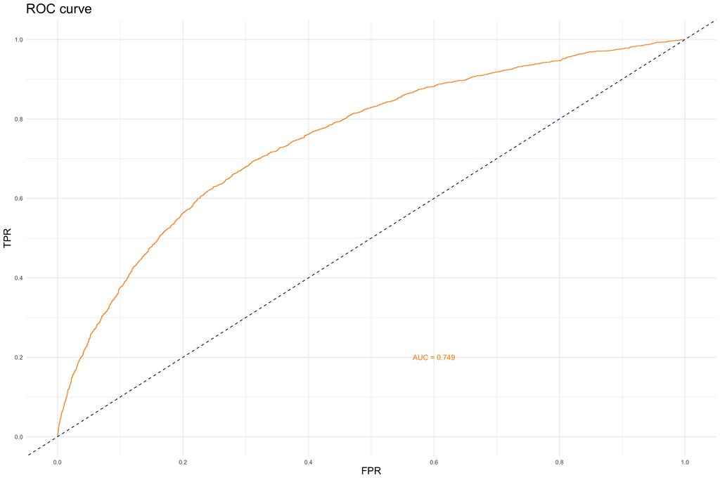

```r
# Plt ROC Curve
# Calculate FPR, TPR, and thresholds
roc_data <- roc(test_data_1$TARGET, test_pred)
fpr <- roc_data$specificities
tpr <- roc_data$sensitivities
thresholds <- roc_data$thresholds

# Calculate AUC
auc <- auc(roc_data)

# Plot ROC curve
ggplot() +
    geom_line(data = data.frame(fpr = 1-fpr, tpr = tpr), aes(x = fpr, y = tpr), color = "darkorange") +
    geom_abline(slope = 1, intercept = 0, linetype = "dashed", color = "navy") +
    scale_x_continuous(limits = c(0, 1), breaks = seq(0, 1, 0.2)) +
    scale_y_continuous(limits = c(0, 1), breaks = seq(0, 1, 0.2)) +
    labs(title = "ROC curve",
         x = "FPR",
         y = "TPR") +
    annotate(
        "text", x = 0.6, y = 0.2,
        label = paste0("AUC = ", round(auc, 3)),
        color = "darkorange"
    ) +
    theme_minimal() +
    theme(plot.title = element_text(size = 20),
          axis.title = element_text(size = 15))
```

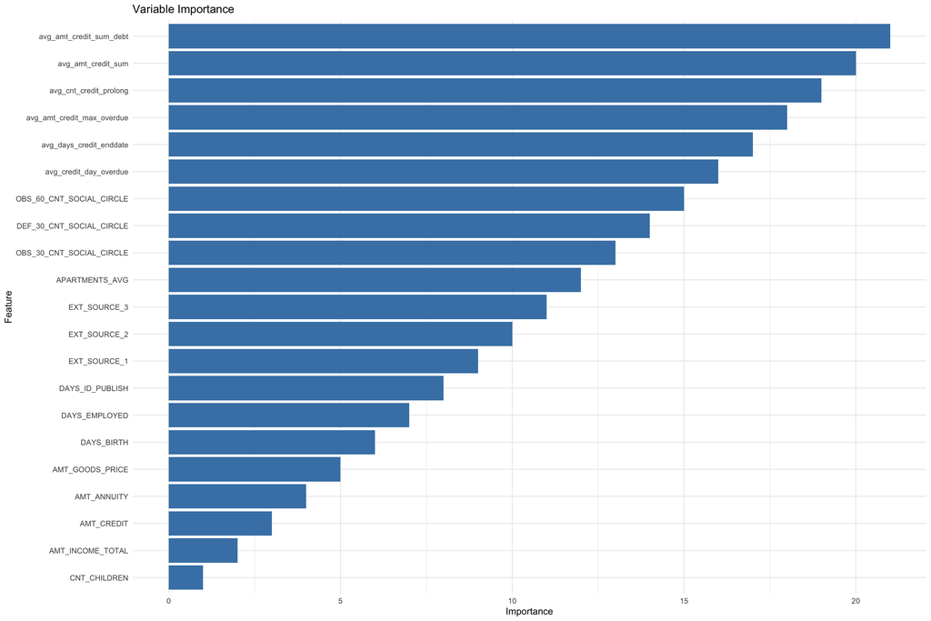

```r
# Create display_importances function
display_importances <- function(feature_importance_df_) {
    feature_importance_df_ <- feature_importance_df_ %>%
        arrange(desc(importance))

    plt <- ggplot(feature_importance_df_, aes(x = importance, y = reorder(feature, importance, max))) +
        geom_bar(stat = "identity", fill = "steelblue") +
        labs(title = "Variable Importance",
             x = "Importance",
             y = "Feature") +
        theme_minimal()

    print(plt)
}

# Get the important feature names
important_features <- colnames(significant_rows)[-1]

# Calculate the importance values based on the number of features
importance_values <- 1:length(important_features)

# Create the feature_importance_df data frame
feature_importance_df <- data.frame(
    feature = important_features,
    importance = importance_values
)

# Call the display_importance function to get variable importance plot
display_importances(feature_importance_df)
```

Based on the analysis of the logistic regression model, the variables avg_amt_credit_sum_debt have the most significant impact on the outcome values. These variables, along with the credit_sum and max_overdue, play an important role in predicting the outcomes.

In addition to the external data sources, other important variables for predicting outcomes include the days_employed and days_birth.

## 4.2 XGBoost Model Performance

XGBoost model was used to predict the classification of applications as No Default = 0 or Default = 1. No Default (TARGET = 0) was defined as a positive prediction for the purposes of analysis.

```r
# Predict classification on test split of app_train2
xgb.pred <- predict(xgb.model,testTask)
```

[output not shown]

```r
# ConfusionMatrix of prediction results
confusionMatrix(xgb.pred$data$response,xgb.pred$data$truth)
```

```
## Confusion Matrix and Statistics
##
##           Reference
## Prediction     0     1
##          0 71283  5590
##          1  1546   557
##
##                Accuracy : 0.9096
##                  95% CI : (0.9076, 0.9116)
##     No Information Rate : 0.9222
##     P-Value [Acc > NIR] : 1
##
##                   Kappa : 0.0993
##
##  Mcnemar's Test P-Value : <2e-16
##
##             Sensitivity : 0.97877
##             Specificity : 0.09061
##          Pos Pred Value : 0.92728
##          Neg Pred Value : 0.26486
##              Prevalence : 0.92217
##          Detection Rate : 0.90259
##    Detection Prevalence : 0.97337
##       Balanced Accuracy : 0.53469
##
##        'Positive' Class : 0
##
```

Two metrics were examined for model comparison based upon business objectives. Specificity (TNR) and Recall (TPR) were computed. TPR was most informative as it is the complement of miss rate (FNR) which was the measure we sought to minimize.

```r
TP <- 71398
TN <- 597
FN <- 5550
FP <- 1431

TPR <- TP / ( TP + FP )
TNR <- TN / ( TN + FN )
```

## 4.3 Random Forest Model Performance

```r
varImpPlot(rf.model)

predicted <- predict(rf.model, dt.test)

table(predicted, dt.test$TARGET)

rf_TP <- 69926
rf_TN <- 6
rf_FN <- 5876
rf_FP <- 5

rf_TPR <- rf_TP / ( rf_TP + rf_FP )
rf_TNR <- rf_TN / ( rf_TN + rf_FN )

rf_TPR
rf_TNR

rf.model
```

## 4.4 Support Vector Machine

```r
svm_final_confmat <- confusionMatrix(factor(final_preds$pred), xtest$target)
```

Given the business case, it seems wise to optimize around maximizing Specificity (if target class = 0) since the cost of default likely far exceeds the opportunity cost of a new customer. This model finished with an unimpressive 86.3% accuracy and a surprisingly hard to achieve 9.75% Specificity.

```r
svm_final_confmat
```

```
## Confusion Matrix and Statistics
##
##           Reference
## Prediction     0     1
##          0 45041  3677
##          1  3516   397
##
##                Accuracy : 0.8633
##                  95% CI : (0.8604, 0.8663)
##     No Information Rate : 0.9226
##     P-Value [Acc > NIR] : 1.00000
##
##                   Kappa : 0.0255
##
##  Mcnemar's Test P-Value : 0.05922
##
##             Sensitivity : 0.92759
##             Specificity : 0.09745
##          Pos Pred Value : 0.92452
##          Neg Pred Value : 0.10146
##              Prevalence : 0.92259
##          Detection Rate : 0.85579
##    Detection Prevalence : 0.92565
##       Balanced Accuracy : 0.51252
##
##        'Positive' Class : 0
##
```

# 5 Results

Though the SVM model yielded the highest Specificity, the XGB model’s Specificity was not far behind and boasted a superior overall accuracy. This is the model we would propose to move forward with and also the model we submitted to Kaggle. The public score it received was 0.5211.

The common pain point expressed through this process was the sheer volume of the data. Realizing exactly how to trim the data occurs only after modeling begins and any trimming during even an extensive EDA is to some degree assumptive. With a smaller and tidier data set, more hyperparameter tuning and other experimentation can be done which ideally results in more predictive models.

# 6 Contributions

- Roman Brock
  - Random Forest
- Che Diaz Fadel
  - Support Vector Machine
- Kalyani Joshi
  - Logistic Regression
- Chris Porter
  - XGBoost